# ME323 - Introdução aos Modelos Probabilísticos

## Probabilidade

## Experimento: Lançamento de 3 moedas

Lançar 3 moedas honestas simultaneamente, e observar a face voltada para cima.

> \[\Omega= \{ (CCC), (CCX),(CXC),(XCC),(XXC),(XCX),(CXX),(XXX)\}\]

> Moedas honestas, então cada elemento do espaço amostral tem igual probabilidade de ocorrer: 1/8

> Qual é a probabilidade de obtermos 3 caras?

> \(A=\{(CCC)\}\)

> \[P(A)=\frac{\mbox{número de elementos em A}}{\mbox{número de elementos em $\Omega$}}= \frac{1}{8}\]

## Experimento: Lançamento de 3 moedas

> Qual a probabilidade de obtermos pelo menos 2 caras?

> \(B=\{(CCC),(CCX),(CXC),(XCC)\}\)

> \[P(B)=\frac{\mbox{número de elementos em B}}{\mbox{número de elementos em $\Omega$}}= \frac{4}{8}=\frac{1}{2}\]

## Jogo de dados

Dois dados honestos são lançados simultaneamente

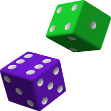

O jogador deve escolher uma das duas opções antes do lançamento dos dados. Caso a opção escolhida ocorra, ele será o vencedor.

As duas opções são:

- **Opção A:** Soma das duas faces é igual a 7;
- **Opção B:** Maior valor obtido nos dois dados seja no máximo 3.

Qual das duas possibilidades ele deve escolher?

## Jogo de dados

Dois dados honestos são lançados simultaneamente

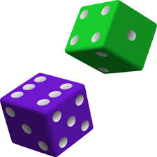

Espaço amostral:

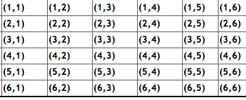

Dados honestos, então cada elemento do espaço amostral tem igual probabilidade de ocorrer: 1/36

## Jogo de dados

**Opção A:** Soma das duas faces é igual a 7.

\(A = \{\mbox{conjunto dos pares } (i,j) \mbox{ tais que } i + j = 7\}\)

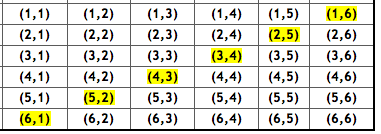

\(A=\{(1,6),(2,5),(3,4),(4,3),(5,2),(6,1)\}\)

\[P(A)=\frac{\mbox{número de elementos em A}}{\mbox{número de elementos em $\Omega$}}=\frac{6}{36} = \frac{1}{6}\]

## Jogo de dados

**Opção B:** Maior valor obtido nos dois dados seja no máximo 3.

\(B=\{\mbox{conjunto dos pares } (i,j) \mbox{ tais que } i \leq 3 \mbox{ e } j \leq 3 \}\)

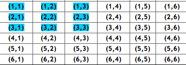

\(B=\{(1,1), (1,2), (1,3), (2,1), (2,2), (2,3), (3,1), (3,2), (3,3)\}\)

\[P(B) = \frac{\mbox{número de elementos em B}}{\mbox{número de elementos em $\Omega$}} = \frac{9}{36} = \frac{1}{4}\]

Como \(P(A) < P(B)\) é mais vantajoso escolher a opção B.

## Regras de Contagem

## Regras de contagem

- Espaço amostral finito \(\Omega=\{\omega_1, \ldots, \omega_n\}\) com elementos equiprováveis, então:

\[P(A) = \frac{\mbox{número de elementos no evento A}}{\mbox{número de elementos no espaço amostral}}.\]

- Precisamos conhecer regras de contagem para calcular probabilidade de eventos.

**Exemplo:** Em um grupo de 100 pessoas, 2 são daltônicas. Dez pessoas são escolhidas ao acaso e sem reposição. Qual a probabilidade de escolhermos apenas uma pessoa daltônica?

De quantas maneiras podemos selecionar 10 pessoas a partir de um grupo de 100 pessoas, sem reposição?

## Regra da adição

**Regra da adição:** suponha que temos dois procedimentos possíveis para executarmos uma tarefa, ou seja, basta executarmos um dos dois procedimentos para que a tarefa tenha sido executada.

O procedimento \(P_1\) tem \(n_1\) formas de ser executado e o procedimento \(P_2\) tem \(n_2\) formas de ser executado.

O total de maneiras para executarmos a tarefa é então dado por \(n_1+n_2\).

## Regra da adição

**Exemplo:** Entre as opções de sobremesa de um restaurante, você pode escolher entre sorvete e torta.

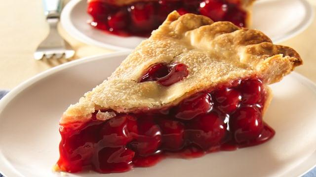

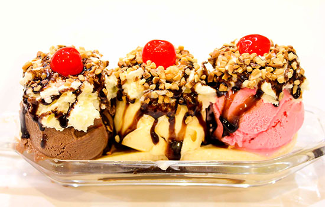

Há dois sabores de torta: baunilha ou cereja.  
Há três sabores de sorvete: morango, chocolate e creme.

Quantas opções você tem no total?

Você pode escolher torta OU sorvete, então existem \(2 + 3= 5\) opções.

## Regra da multiplicação

**Regra da multiplicação:** suponha que para realizarmos uma tarefa temos que executar dois procedimentos, denotados por \(P_1\) e \(P_2\).

O procedimento \(P_1\) tem \(n_1\) formas de ser executado e o procedimento \(P_2\) tem \(n_2\) formas de ser executado.

O total de maneiras para executarmos a tarefa é dado por \(n_1 \times n_2\).

## Regra da multiplicação

**Exemplo:** Você vai no Spoleto e vê no cardápio "[Monte sua Massa](http://www.spoleto.com.br/monteseuprato/massas?refogar=1)".

| Tipo de Massa | Tamanho | Molho | Gratinar? |
| --- | --- | --- | --- |
| Farfale | Bambini | Bolognesa | Sim |
| Fettuccine | Normal | Branco | Não |
| Fusili Integrale | Mamma | Funghi |  |
| Penne |  | 4 Queijos |  |
| Spaghetti |  | Tomate |  |

Quantas opções de pratos você têm no total?

Você pode criar \(5 \times 3 \times 5 \times 2= 150\) pratos diferentes.

## Exemplo: Sobremesas

Você volta no mesmo restaurante das tortas e sorvetes. Há dois sabores de torta (baunilha ou cereja) e três sabores de sorvete (morango, chocolate e creme).

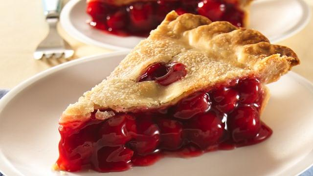

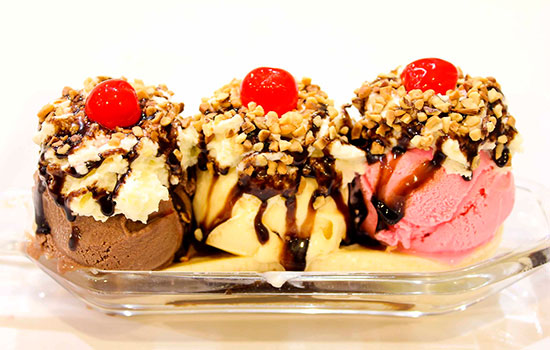

Apenas aos sábados, o restaurante oferece a "Torta da Casa", que é uma torta com sorvete em cima. Aos sábados, quantas opções de sobremesa você?

- \(2+3= 5\) opções caso não escolha "Torta da Casa".
- \(2\times 3= 6\) opções de "Torta da Casa".
- Total: 11 opções de sobremesa.

## Exemplo: Placa de carro

De quantas formas diferentes podemos escolher a placa de um carro, tendo essa 3 letras e 4 números?

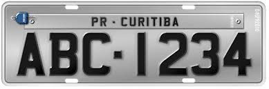

> \[ 26 \times 26 \times 26 \times 10 \times 10 \times 10 \times 10 = 175.760.000\]

> E se não pudesse haver repetição de letras e números?

> \[ 26 × 25 × 24 × 10 × 9 × 8 × 7 = 78.624.000\]

## Permutação

Suponha que tenhamos uma coleção \(O=\{w_1,w_2,...,w_n\}\) de \(n\) objetos. De quantas maneiras podemos permutar (dispor) estes elementos?

O número de maneiras que podemos fazer isto é denominado **permutação**.

Suponha que temos \(n\) caixas e queremos dispor os \(n\) objetos de \(O\) nessas caixas.

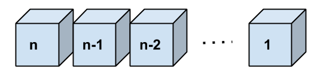

> Aplicando a regra da multiplicação, temos que o número de maneiras de permutar \(n\) elementos é: \[n\times(n-1)\times\ldots\times1=n!\]

## Exemplos

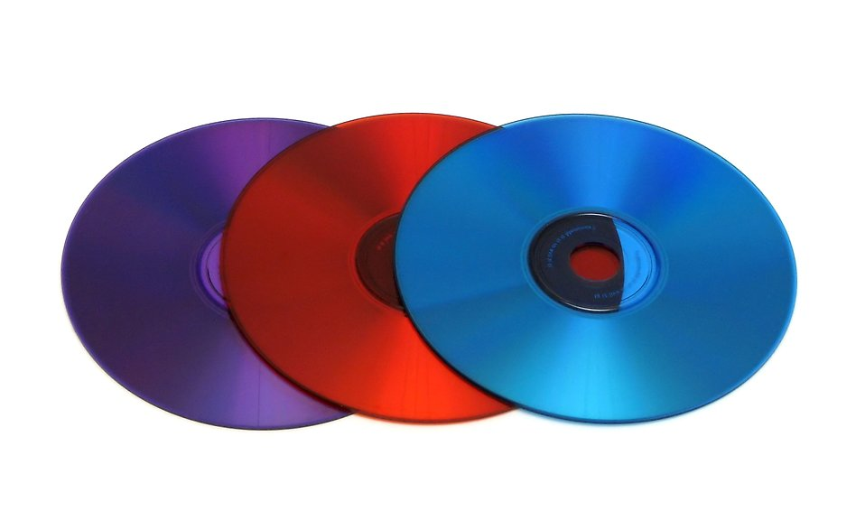

**Exemplo 1**: Se tivermos três CD's (\(a\), \(b\) e \(c\)). De quantas formas diferentes posso distribuí-los para três amigos?

> \[3! = 3 \times 2 \times 1 = 6 \]

> Ou seja, temos as seguintes permutações: \[abc, acb, bac, bca, cab, cba\]

**Exemplo 2**: Quantos anagramas podemos formar com a palavra ERVILHAS, sendo que eles comecem com a letra E e terminem com vogal?

> \[ 1 \times 6! \times 2 = 1440\]

## Permutação

Suponha que queremos permutar \(n\) objetos, mas alguns deles são indistinguíveis.

> **Exemplo**: Quantos anagramas podemos formar com a palavra PEPPER?

> Seria \(6! = 720\), certo?

> Mas note que P<sup>1</sup>E<sup>1</sup>P<sup>2</sup>P<sup>3</sup>E<sup>2</sup>R = P<sup>2</sup>E<sup>1</sup>P<sup>1</sup>P<sup>3</sup>E<sup>2</sup>R

> Na verdade, existem \(3! 2! = 12\) permutações quer resultam no mesmo anagrama

> Portanto, o número de possíveis anagramas distintos é:

\[\frac{6!}{3!2!} = 60\]

## Arranjo

Suponha que tenhamos uma coleção \(O=\{w_1,w_2,...,w_n\}\) de \(n\) objetos.

> De quantas maneiras podemos escolher \(r\) destes elementos?

> O número de maneiras que podemos fazer isto é denominado **arranjo**.

> Suponha que temos \(r\) caixas e queremos dispor os \(n\) objetos de \(O\) nessas caixas.

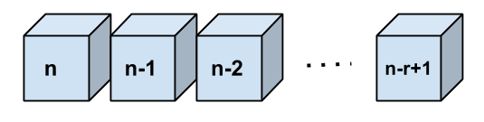

## Arranjo

> Aplicando a regra da multiplicação, temos que o número de maneiras de arranjar \(n\) elementos em \(r\) caixas é: \[n \times(n-1) \times \ldots \times (n-r+1) = \frac{n!}{(n-r)!} = A(n,r)\]

**Exemplo:** Se tivermos os objetos \(a\), \(b\), \(c\) e \(d\), de quantas maneiras podemos escolher 2 elementos:

> \[A(4, 2) = \frac{4!}{(4-2)!} = 12,\]

> que seriam as seguintes: \(ab,ac,ad,ba,bc,bd,ca,cb,cd,da,db,dc\).

## Combinação

Suponha que tenhamos uma coleção \(O=\{w_1,w_2,...,w_n\}\) de \(n\) objetos.

> De quantas maneiras podemos escolher \(r\) destes elementos sem considerarmos a ordem?

> O número de maneiras que podemos fazer isto é denominado **combinação**.

> O número de maneiras de alocarmos os \(n\) objetos em \(r\) caixas é:

> \[A(n,r) = \frac{n!}{(n-r)!}\]

> Como a ordem não importa, após alocarmos os \(r\) objetos, temos \(r!\) formas de permutá-los.

## Combinação

Então o número de maneiras de escolhermos \(r\) objetos sem importar a ordem dentre \(n\) objetos é: \[\frac{A(n,r)}{r!} = \frac{n!}{r!(n-r)!}=\binom{n}{r}=C(n,r)\]

**Exemplo:** Se tivermos os objetos \(a\), \(b\), \(c\) e \(d\), de quantas maneiras podemos escolher 2 elementos sem considerar a ordem?

> \[ C(4, 2) = \binom{4}{2} = 6,\]

> que seriam as seguintes: \(ab,ac,ad,bc,bd,cd\).

## Exemplo

Sete atletas estão competindo nas olimpíadas. O pódium tem 3 lugares: ouro, prata e bronze. Quantos pódiuns podem ser feitos?

[figure not shown]

- A ordem importa (ouro, prata e bronze):

> \[7 \times 6 \times 5 = 210\]

> \[A(7,3)=\frac{7!}{(7-3)!}= 210\]
- A ordem não importa:

> \[C(7,3)=\frac{7!}{3!(7-3)!}= 35\]

## Exemplo

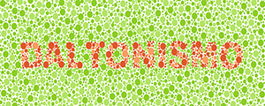

Em um grupo de 100 pessoas, 2 são daltônicas. Dez pessoas são escolhidas ao acaso e sem reposição.

Qual a probabilidade de escolhermos apenas uma pessoa daltônica?

> De quantas maneiras podemos selecionar 10 pessoas a partir de um grupo de 100 pessoas, sem reposição?

\[C(100,10)=\binom{100}{10}\]

> De quantas maneiras podemos selecionar 1 pessoa a partir de um grupo de 2 pessoas daltônicas?

\[C(2,1)=\binom{2}{1}\]

## Exemplo

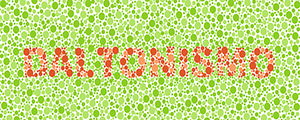

Em um grupo de 100 pessoas, 2 são daltônicas. Dez pessoas são escolhidas ao acaso e sem reposição.

Qual a probabilidade de escolhermos apenas uma pessoa daltônica?

> De quantas maneiras podemos selecionar 9 pessoas a partir de um grupo de 98 pessoas com visão normal?

\[C(98,9)=\binom{98}{9}\]

> Então, a probabilidade de escolhermos apenas uma pessoa daltônica: \[\frac{\binom{2}{1}\binom{98}{9}}{\binom{100}{10}}\]

## Exemplo

Uma caixa contém 2 bolas vermelhas, 3 verdes e 2 azuis. Duas bolas são selecionadas aleatoriamente. Qual a probabilidade de que nenhuma bola seja azul?

- Total de bolas: 7
- Maneiras de sortear 2 bolas dentre 7 bolas: \(C(7,2)=\binom{7}{2}=\frac{7!}{2!(7-2)!}=21\)
- \(A\)=sortear 2 bolas, nenhuma sendo azul.

> \[C(5,2)=\frac{5!}{2!(5-2)!}=10\]

> \[P(A)=\frac{10}{21}\]

## Exemplo

Em uma classe, há 15 meninos e 10 meninas. Três alunos são selecionados ao acaso. Qual a probabilidade de sortear 1 menina e 2 meninos?

- Maneiras de sortear 3 alunos dentre 25:  
  \(C(25,3)=\binom{25}{3}=\frac{25!}{3!(25-33)!}= 2300\)
- \(A\)=sortear 1 menina e 2 meninos.

> \(C(10,1) = \frac{10!}{1!(10-1)!}= 10 \;\;\;\;\;\) e \(\;\;\;\;\; C(15,2) = \frac{15!}{2!(15-2)!}= 105\)

> Número de elementos em \(A\)= \(C(10,1)\) x \(C(15,2) = 1050\).

> \[P(A)=\frac{1050}{2300}=\frac{21}{46}\]

## Exemplo

Uma sacola tem 4 bolas brancas, 5 vermelhas e 6 azuis. Três bolas são selecionadas ao acaso da sacola. Qual a probabilidade de que todas elas sejam vermelhas?

- Total de bolas: 15
- Maneiras de sortear 3 bolas dentre 15 bolas:  
  \(C(15, 3)=\binom{15}{3}=\frac{15!}{3!(15-3)!}=455\)
- \(A\)=sortear 3 bolas vermelhas.

> \[C(5, 3)=\frac{5!}{3!(5-3)!}=10\]

> \[P(A)=\frac{10}{455}=\frac{2}{91}\]

## Aniversários no mesmo dia?

> Nessa sala com mais de 100 alunos, quantas pessoas vocês acham que fazem aniversário no mesmo dia?

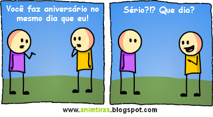

> Eu aposto que existem pelo menos um par de pessoas que fazem aniversário no mesmo dia!!!

> Vamos verificar?

## Paradoxo do Aniversário

Para calcular a probabilidade de que em uma sala com \(n\) pessoas, pelo menos duas possuam o mesmo aniversário: desprezamos variações na distribuição, tais como anos bissextos, gêmeos, variações sazonais ou semanais, e assumimos que 365 possíveis aniversários são todos igualmente prováveis.

É mais fácil calcular a probabilidade do evento \(A\), definido como todos os \(n\) aniversários são diferentes:

\[\begin{eqnarray} P(A)&=&1\cdot \left(1-{\frac {1}{365}}\right)\cdot \left(1-{\frac {2}{365}}\right)\cdots \left(1-{\frac {n-1}{365}}\right)\\ &=&{365\cdot 364\cdots (365-n+1) \over 365^{n}}\\ &=&{365! \over 365^{n}(365-n)!} \end{eqnarray}\]

## Paradoxo do Aniversário

O evento de pelo menos duas pessoas entre \(n\) terem o mesmo aniversário (chamaremos de evento \(B\)) é o complementar de todos \(n\) serem diferentes (evento \(A\)).

Consequentemente, sua probabilidade é:

\[P(B)=1-P(A)\]

## Paradoxo do Aniversário

Qual é a probabilidade de pelo menos uma coincidência?

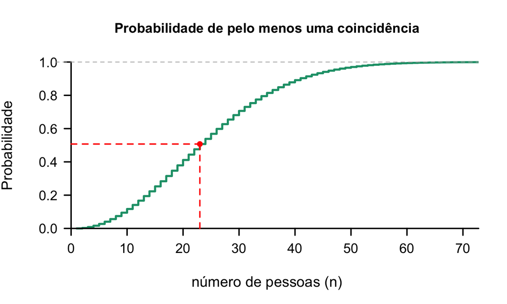

## Exemplo

Quantos números de 4 dígitos podemos formar com os dígitos 1, 2, 3, 4, 5, 6?

> \(6 ^4=1296\) (com reposição)

> Qual a probabilidade de se escolher um número dentre os 1296 e este possuir os dois primeiros dígitos iguais entre si, e os dois últimos, diferentes desses primeiros?
- Para o primeiro dígito, temos 6 possibilidades.
- Para o segundo dígito, temos 1 possibilidade, pois ele deve ser igual ao primeiro.
- Para o terceiro dígito, temos 5 possibilidades, pois ele deve ser diferente do primeiro (e do segundo).
- Para o quarto dígito, temos 5 possibilidades, pois ele deve ser diferente do primeiro (e do segundo).

> A probabilidade é

\[\frac{6 \times 1 \times 5 \times 5}{1296}= \frac{25}{216} \approx 0.12\]

## Leituras

- [Ross](http://www.sciencedirect.com/science/book/9780123743886): capítulo 4
- [OpenIntro](https://www.openintro.org/stat/textbook.php): seções 2.1. e 2.2
- Magalhães: capítulo 2
- Devore: capítulo 2

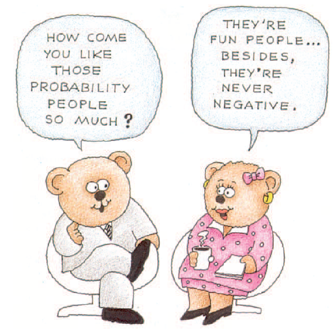

Slides produzidos pelos professores:

- Samara Kiihl
- Tatiana Benaglia
- Benilton Carvalho